# Markovian Analysis On Argentine Game Result

**Project Summary** A Markov chain or Markov process is a stochastic model describing a sequence of possible events in which the probability of each event depends only on the state attained in the previous event.Here data set containing football teams associated with fifa are used to predict the probability of Argentine National Football team to predict the outcome of nth match.

Later we also used the multinational process on Markov chain to predict the trend of the outcome of the match after n matches.

**Importing Necessary Libraries**

```r
library(dplyr)
library(data.table)
library(markovchain)
library(diagram)
library(expm)
library(pracma)
library(ggplot2)
```

**Importing dataset from csv file** This dataset contains necessary data for fotball teams associated with fifa. dataset includes features such as team names, date of match, result of the match, fifa rank of the, information regarding the venue etc.

```r
team=read.csv("matches.csv",header=TRUE,sep=",")
class(team)
```

```
[1] "data.frame"
```

```r
team
```

| date | home_team | away_team | home_team_continent | away_team_continent | home_team_fifa_rank | away_team_fifa_rank | home_team_total_fifa_points | away_team_total_fifa_points | home_team_score | away_team_score | tournament | city | country | neutral_location | shoot_out | home_team_result | home_team_goalkeeper_score | away_team_goalkeeper_score | home_team_mean_defense_score | home_team_mean_offense_score | home_team_mean_midfield_score | away_team_mean_defense_score | away_team_mean_offense_score | away_team_mean_midfield_score |
| --- | --- | --- | --- | --- | --- | --- | --- | --- | --- | --- | --- | --- | --- | --- | --- | --- | --- | --- | --- | --- | --- | --- | --- | --- |
| 1993-08-08 | Bolivia | Uruguay | South America | South America | 59 | 22 | 0 | 0 | 3 | 1 | FIFA World Cup qualification | La Paz | Bolivia | False | No | Win | NA | NA | NA | NA | NA | NA | NA | NA |
| 1993-08-08 | Brazil | Mexico | South America | North America | 8 | 14 | 0 | 0 | 1 | 1 | Friendly | Maceió | Brazil | False | No | Draw | NA | NA | NA | NA | NA | NA | NA | NA |
| 1993-08-08 | Ecuador | Venezuela | South America | South America | 35 | 94 | 0 | 0 | 5 | 0 | FIFA World Cup qualification | Quito | Ecuador | False | No | Win | NA | NA | NA | NA | NA | NA | NA | NA |
| 1993-08-08 | Guinea | Sierra Leone | Africa | Africa | 65 | 86 | 0 | 0 | 1 | 0 | Friendly | Conakry | Guinea | False | No | Win | NA | NA | NA | NA | NA | NA | NA | NA |
| 1993-08-08 | Paraguay | Argentina | South America | South America | 67 | 5 | 0 | 0 | 1 | 3 | FIFA World Cup qualification | Asunción | Paraguay | False | No | Lose | NA | NA | NA | NA | NA | NA | NA | NA |
| 1993-08-08 | Peru | Colombia | South America | South America | 70 | 19 | 0 | 0 | 0 | 1 | FIFA World Cup qualification | Lima | Peru | False | No | Lose | NA | NA | NA | NA | NA | NA | NA | NA |
| 1993-08-08 | Zimbabwe | Eswatini | Africa | Africa | 50 | 102 | 0 | 0 | 2 | 0 | Friendly | Harare | Zimbabwe | False | No | Win | NA | NA | NA | NA | NA | NA | NA | NA |
| 1993-08-09 | Guinea | Sierra Leone | Africa | Africa | 65 | 86 | 0 | 0 | 4 | 0 | Friendly | Conakry | Guinea | False | No | Win | NA | NA | NA | NA | NA | NA | NA | NA |
| 1993-08-11 | Faroe Islands | Norway | Europe | Europe | 111 | 9 | 0 | 0 | 0 | 7 | Friendly | Toftir | Faroe Islands | False | No | Lose | NA | NA | NA | NA | NA | NA | NA | NA |
| 1993-08-11 | Sweden | Switzerland | Europe | Europe | 4 | 3 | 0 | 0 | 1 | 2 | Friendly | Borås | Sweden | False | No | Lose | NA | NA | NA | NA | NA | NA | NA | NA |

[output cut: 990 more lines]

**Data preprocessing** The dataset needs a bit of preprocessing as only informatuon regarting the Argentine Football team will be used.

```r
team=read.csv("matches.csv",header=TRUE,sep=",")
#team
arg=team[team$home_team == 'Argentina' | team$away_team == 'Argentina',]
arg
```

|  | date | home_team | away_team | home_team_continent | away_team_continent | home_team_fifa_rank | away_team_fifa_rank | home_team_total_fifa_points | away_team_total_fifa_points | home_team_score | away_team_score | tournament | city | country | neutral_location | shoot_out | home_team_result | home_team_goalkeeper_score | away_team_goalkeeper_score | home_team_mean_defense_score | home_team_mean_offense_score | home_team_mean_midfield_score | away_team_mean_defense_score | away_team_mean_offense_score | away_team_mean_midfield_score |
| --- | --- | --- | --- | --- | --- | --- | --- | --- | --- | --- | --- | --- | --- | --- | --- | --- | --- | --- | --- | --- | --- | --- | --- | --- | --- |
| 5 | 1993-08-08 | Paraguay | Argentina | South America | South America | 67 | 5 | 0 | 0 | 1 | 3 | FIFA World Cup qualification | Asunción | Paraguay | False | No | Lose | NA | NA | NA | NA | NA | NA | NA | NA |
| 13 | 1993-08-15 | Colombia | Argentina | South America | South America | 19 | 5 | 0 | 0 | 2 | 1 | FIFA World Cup qualification | Barranquilla | Colombia | False | No | Win | NA | NA | NA | NA | NA | NA | NA | NA |
| 16 | 1993-08-22 | Argentina | Peru | South America | South America | 5 | 70 | 0 | 0 | 2 | 1 | FIFA World Cup qualification | Buenos Aires | Argentina | False | No | Win | NA | NA | NA | NA | NA | NA | NA | NA |
| 23 | 1993-08-29 | Argentina | Paraguay | South America | South America | 5 | 67 | 0 | 0 | 0 | 0 | FIFA World Cup qualification | Buenos Aires | Argentina | False | No | Draw | NA | NA | NA | NA | NA | NA | NA | NA |
| 28 | 1993-09-05 | Argentina | Colombia | South America | South America | 5 | 19 | 0 | 0 | 0 | 5 | FIFA World Cup qualification | Buenos Aires | Argentina | False | No | Lose | NA | NA | NA | NA | NA | NA | NA | NA |
| 118 | 1993-10-31 | Australia | Argentina | Oceania | South America | 61 | 9 | 0 | 0 | 1 | 1 | FIFA World Cup qualification | Sydney | Australia | False | No | Draw | NA | NA | NA | NA | NA | NA | NA | NA |
| 130 | 1993-11-17 | Argentina | Australia | South America | Oceania | 9 | 61 | 0 | 0 | 1 | 0 | FIFA World Cup qualification | Buenos Aires | Argentina | False | No | Win | NA | NA | NA | NA | NA | NA | NA | NA |
| 165 | 1993-12-15 | Argentina | Germany | South America | Europe | 9 | 3 | 0 | 0 | 2 | 1 | Friendly | Miami | USA | True | No | Win | NA | NA | NA | NA | NA | NA | NA | NA |
| 251 | 1994-03-23 | Brazil | Argentina | South America | South America | 2 | 8 | 0 | 0 | 2 | 0 | Friendly | Recife | Brazil | False | No | Win | NA | NA | NA | NA | NA | NA | NA | NA |
| 289 | 1994-04-20 | Argentina | Morocco | South America | Africa | 10 | 26 | 0 | 0 | 3 | 1 | Friendly | Salta | Argentina | False | No | Win | NA | NA | NA | NA | NA | NA | NA | NA |

[output cut: 357 more lines]

```r
#at = team[team$away_team == 'Argentina',]
#head(at, 10)
```

Result isolation and modification is done here so as the results of the home team is given. Therefore a bit of modifiaction is done so that results are given when Argentine Team is both home and away. It is stored in “argentina_result” and allocated in a new dataset cal “new_df”. After that only the “argentina_result” column is segrated which would be used in the Markov Chain process. The states in the “argentina_result” columns are Win,Lose or Draw.

```r
new_df<-arg%>%mutate(argentina_result= case_when(away_team =='Argentina' & home_team_result == 'Win' ~ 'Lose',
                          away_team =='Argentina' & home_team_result == 'Lose' ~ 'Win',
                          away_team =='Argentina' & home_team_result == 'Draw' ~ 'Draw',
                          home_team =='Argentina' & home_team_result == 'Win' ~ 'Win',
                          home_team =='Argentina' & home_team_result == 'Lose' ~ 'Lose',
                          home_team =='Argentina' & home_team_result == 'Draw' ~ 'Draw',

                          ))
new_df
```

|  | date | home_team | away_team | home_team_continent | away_team_continent | home_team_fifa_rank | away_team_fifa_rank | home_team_total_fifa_points | away_team_total_fifa_points | home_team_score | away_team_score | tournament | city | country | neutral_location | shoot_out | home_team_result | home_team_goalkeeper_score | away_team_goalkeeper_score | home_team_mean_defense_score | home_team_mean_offense_score | home_team_mean_midfield_score | away_team_mean_defense_score | away_team_mean_offense_score | away_team_mean_midfield_score | argentina_result |
| --- | --- | --- | --- | --- | --- | --- | --- | --- | --- | --- | --- | --- | --- | --- | --- | --- | --- | --- | --- | --- | --- | --- | --- | --- | --- | --- |
| 5 | 1993-08-08 | Paraguay | Argentina | South America | South America | 67 | 5 | 0 | 0 | 1 | 3 | FIFA World Cup qualification | Asunción | Paraguay | False | No | Lose | NA | NA | NA | NA | NA | NA | NA | NA | Win |
| 13 | 1993-08-15 | Colombia | Argentina | South America | South America | 19 | 5 | 0 | 0 | 2 | 1 | FIFA World Cup qualification | Barranquilla | Colombia | False | No | Win | NA | NA | NA | NA | NA | NA | NA | NA | Lose |
| 16 | 1993-08-22 | Argentina | Peru | South America | South America | 5 | 70 | 0 | 0 | 2 | 1 | FIFA World Cup qualification | Buenos Aires | Argentina | False | No | Win | NA | NA | NA | NA | NA | NA | NA | NA | Win |
| 23 | 1993-08-29 | Argentina | Paraguay | South America | South America | 5 | 67 | 0 | 0 | 0 | 0 | FIFA World Cup qualification | Buenos Aires | Argentina | False | No | Draw | NA | NA | NA | NA | NA | NA | NA | NA | Draw |
| 28 | 1993-09-05 | Argentina | Colombia | South America | South America | 5 | 19 | 0 | 0 | 0 | 5 | FIFA World Cup qualification | Buenos Aires | Argentina | False | No | Lose | NA | NA | NA | NA | NA | NA | NA | NA | Lose |
| 118 | 1993-10-31 | Australia | Argentina | Oceania | South America | 61 | 9 | 0 | 0 | 1 | 1 | FIFA World Cup qualification | Sydney | Australia | False | No | Draw | NA | NA | NA | NA | NA | NA | NA | NA | Draw |
| 130 | 1993-11-17 | Argentina | Australia | South America | Oceania | 9 | 61 | 0 | 0 | 1 | 0 | FIFA World Cup qualification | Buenos Aires | Argentina | False | No | Win | NA | NA | NA | NA | NA | NA | NA | NA | Win |
| 165 | 1993-12-15 | Argentina | Germany | South America | Europe | 9 | 3 | 0 | 0 | 2 | 1 | Friendly | Miami | USA | True | No | Win | NA | NA | NA | NA | NA | NA | NA | NA | Win |
| 251 | 1994-03-23 | Brazil | Argentina | South America | South America | 2 | 8 | 0 | 0 | 2 | 0 | Friendly | Recife | Brazil | False | No | Win | NA | NA | NA | NA | NA | NA | NA | NA | Lose |
| 289 | 1994-04-20 | Argentina | Morocco | South America | Africa | 10 | 26 | 0 | 0 | 3 | 1 | Friendly | Salta | Argentina | False | No | Win | NA | NA | NA | NA | NA | NA | NA | NA | Win |

[output cut: 357 more lines]

```r
result = new_df[c("argentina_result")]
result
```

|  | argentina_result |
| --- | --- |
| 5 | Win |
| 13 | Lose |
| 16 | Win |
| 23 | Draw |
| 28 | Lose |
| 118 | Draw |
| 130 | Win |
| 165 | Win |
| 251 | Lose |
| 289 | Win |

[output cut: 357 more lines]

```r
#class(result)
```

**Initiazalition of Transition matrix** State & State Transitions variable are declared here which will be further used to hold the transitional probailities from each and every state.

```r
#win transitions
wtw=0 #->win
wtl=0 #->loss
wtd=0 #->draw

#loss transitions
ltl=0 #->loss
ltw=0 #->win
ltd=0 #->draw

#draw transitions
dtd=0 #->draw
dtw=0 #->win
dtl=0 #->loss
```

```r
#Length of the column
len = lengths(result)-1
len
```

```
argentina_result
             366
```

State transitions occurances are calculated here by iterating over the “argentina_result” column.Transitions include “wtw” referring to “win to win” transition, ““wtl” referring to “win to loss” transitions. This will be used to calculate the probabilities, which are shown in the later steps.

```r
for (i in 1:len){
  if (result[i,] == "Win"){
    if(result[i+1,] == "Win"){
      wtw= wtw + 1
    }
    else if(result[i+1,] == "Lose"){
      wtl= wtl + 1
    }
    else{
      wtd = wtd + 1
    }
  }

  else if (result[i,] == "Lose"){
    if(result[i+1,] == "Lose"){
      ltl= ltl + 1
    }
    else if(result[i+1,] == "Win"){
      ltw= ltw + 1
    }
    else{
      ltd = ltd + 1
    }
  }

  else if (result[i,] == "Draw"){
    if(result[i+1,] == "Draw"){
      dtd= dtd + 1
    }
    else if(result[i+1,] == "Win"){
      dtw= dtw + 1
    }
    else{
      dtl = dtl + 1
    }
  }
}
```

```r
#Result checking
# wtw
# wtl
# wtd
#
# ltl
# ltw
# ltd
#
# dtd
# dtw
# dtl
```

```r
#Number of occurances
# table(result$argentina_result)
# count(filter(result,argentina_result=="Win"))
# count(filter(result,argentina_result=="Lose"))
# count(filter(result,argentina_result=="Draw"))
#Total Number of
wt = wtw+wtl+wtd
lt = ltl+ltw+ltd
dt = dtd+dtw+dtl
```

```r
#Transitional Probabilities
tp_wtw = wtw/wt
tp_wtl = wtl/wt
tp_wtd = wtd/wt

tp_ltl = ltl/lt
tp_ltw = ltw/lt
tp_ltd = ltd/lt

tp_dtd = dtd/dt
tp_dtw = dtw/dt
tp_dtl = dtl/dt

#Result check
# tp_wtw
# tp_wtl
# tp_wtd
#
# tp_ltl
# tp_ltw
# tp_ltd
#
# tp_dtd
# tp_dtw
# tp_dtl
```

**Transitional Matrix** Here the transitional matrix is created usin the above values obtained from the “argentina_result” column itself

```r
#transitional matrix creation
tm_result<- round(matrix(c(tp_wtw,tp_wtl,tp_wtd,
                           tp_ltl,tp_ltw,tp_ltd,
                           tp_dtd,tp_dtw,tp_dtl),nrow = 3, byrow = TRUE),1)

#Assigning state names to rows and columns of the matrix
states = c("Win","Loss","Draw")
row.names(tm_result) <- states
colnames(tm_result) = states
tm_result
```

```
     Win Loss Draw
Win  0.6  0.2  0.2
Loss 0.1  0.7  0.2
Draw 0.3  0.5  0.2
```

**Markov chain creation** Here using a Markov chain object, a discrete markov chain model has been built

```r
transition_matrix_result <- new("markovchain",transitionMatrix=tm_result,
             states=c("Win","Loss","Draw"),
             name="MarkovChain for Argentina Game Result Prediction")
```

```r
#output
transition_matrix_result
```

```
MarkovChain for Argentina Game Result Prediction
 A  3 - dimensional discrete Markov Chain defined by the following states:
 Win, Loss, Draw
 The transition matrix  (by rows)  is defined as follows:
     Win Loss Draw
Win  0.6  0.2  0.2
Loss 0.1  0.7  0.2
Draw 0.3  0.5  0.2
```

**State Diagrams** Our first figure is the Mmatch prediction state diagram

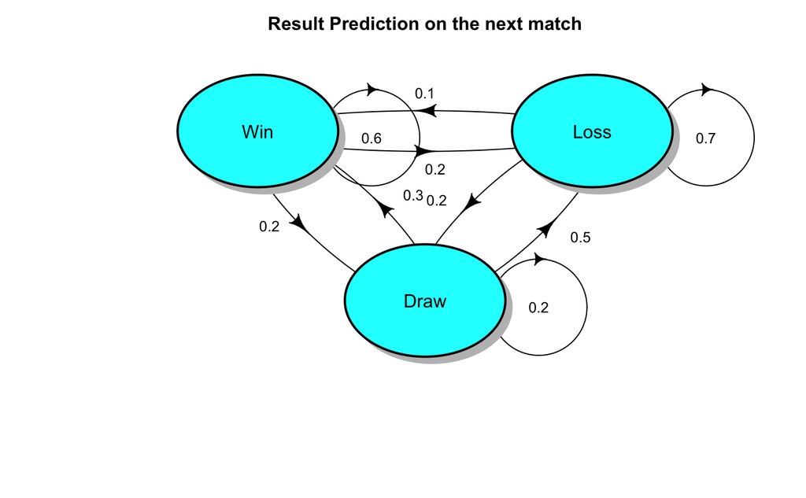

```r
plotmat(t(tm_result),pos = c(2,1),
        lwd = 1, box.lwd = 2,
        cex.txt = 0.8,
        box.size = 0.12,
        box.type = "circle",
        box.prop = 0.7,
        box.col = "cyan",
        arr.length=.4,
        arr.width=.2,
        self.cex = .6,
        self.shifty = -.01,
        self.shiftx = .17,
        main = "Result Prediction on the next match")
```

Here matrix initialization is done to predict the result after n days

```r
initial_state <- matrix(c(1,0,0),nrow=1, byrow=TRUE)
```

Now, let us predict the probilties of the Argentine team result after 1 match

```r
matches <- 1
after_one_match <- round(initial_state * transition_matrix_result ^ matches,1)
after_one_match
```

```
     Win Loss Draw
[1,] 0.6  0.2  0.2
```

```r
after_one_match <- round(tm_result%^%matches,1)
after_one_match
```

```
     Win Loss Draw
Win  0.6  0.2  0.2
Loss 0.1  0.7  0.2
Draw 0.3  0.5  0.2
```

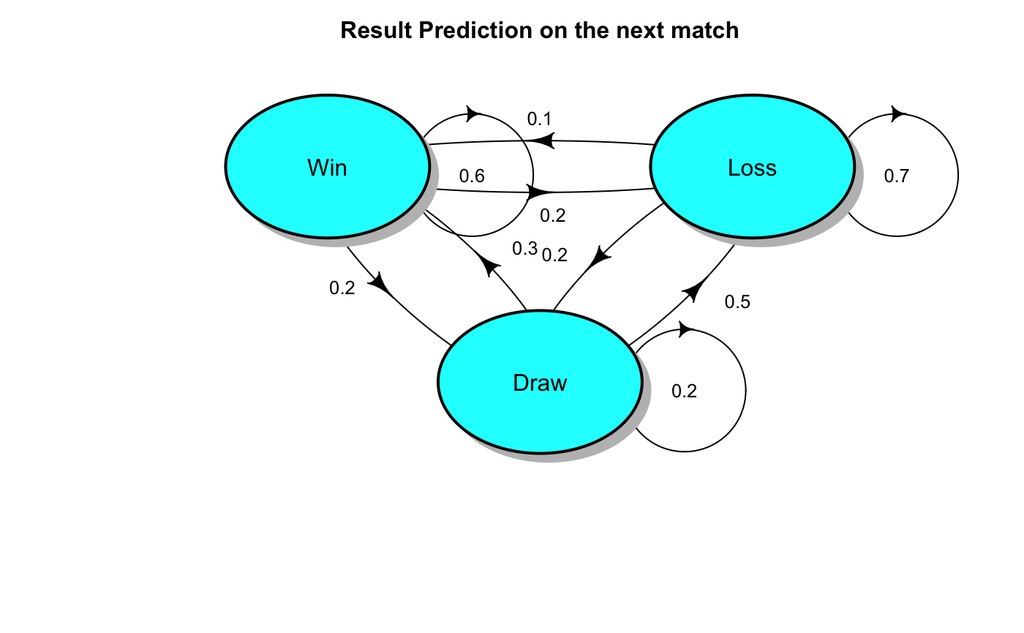

```r
#plot
plotmat(t(after_one_match),pos = c(2,1),
        lwd = 1, box.lwd = 2,
        cex.txt = 0.8,
        box.size = 0.12,
        box.type = "circle",
        box.prop = 0.7,
        box.col = "cyan",
        arr.length=.4,
        arr.width=.2,
        self.cex = .6,
        self.shifty = -.01,
        self.shiftx = .17,
        main = "Result Prediction on the next match")
```

Now, let us predict the probilties of the Argentine team result after 2 matches

```r
matches <-2
after_two_match <- round(initial_state * transition_matrix_result ^ matches,1)
after_two_match
```

```
     Win Loss Draw
[1,] 0.4  0.4  0.2
```

```r
after_two_match <- round(tm_result%^%matches,1)
after_two_match
```

```
     Win Loss Draw
Win  0.4  0.4  0.2
Loss 0.2  0.6  0.2
Draw 0.3  0.5  0.2
```

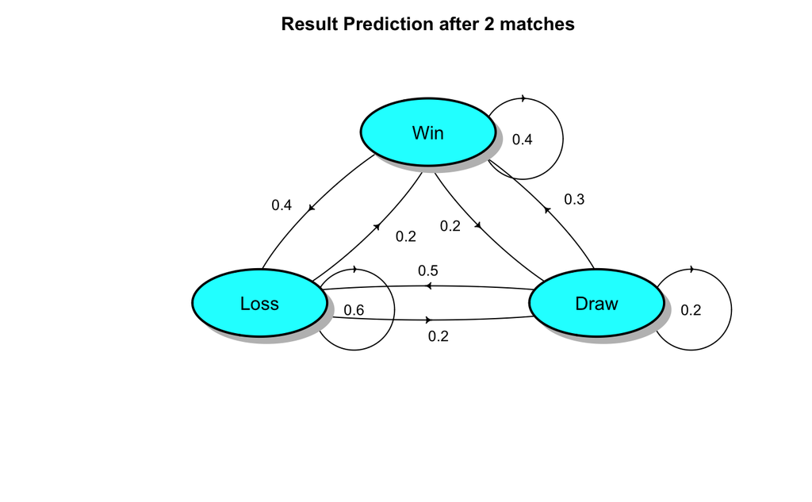

```r
plotmat(t(after_two_match),pos = c(1,2),
        lwd = 1, box.lwd = 2,
        cex.txt = 0.8,
        box.size = 0.1,
        box.type = "circle",
        box.prop = 0.5,
        box.col = "cyan",
        arr.length=.1,
        arr.width=.1,
        self.cex = .6,
        self.shifty = -.01,
        self.shiftx = .14,
        main = "Result Prediction after 2 matches")
```

Now, let us predict the probilties of the Argentine team result after 7 matches

```r
matches <-7
after_two_match <- round(initial_state * transition_matrix_result ^ matches,1)
after_two_match
```

```
     Win Loss Draw
[1,] 0.3  0.5  0.2
```

```r
after_two_match <- round(tm_result%^%matches,1)
after_two_match
```

```
     Win Loss Draw
Win  0.3  0.5  0.2
Loss 0.3  0.5  0.2
Draw 0.3  0.5  0.2
```

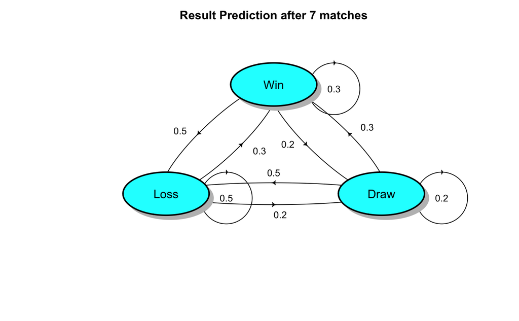

```r
plotmat(t(after_two_match),pos = c(1,2),
        lwd = 1, box.lwd = 2,
        cex.txt = 0.8,
        box.size = 0.1,
        box.type = "circle",
        box.prop = 0.5,
        box.col = "cyan",
        arr.length=.1,
        arr.width=.1,
        self.cex = .6,
        self.shifty = -.01,
        self.shiftx = .14,
        main = "Result Prediction after 7 matches")
```

Now, let us predict the probilties of the Argentine team result after 100 matches

```r
matches <-100
after_hundred_match <- round(initial_state * transition_matrix_result ^ matches,1)
after_hundred_match
```

```
     Win Loss Draw
[1,] 0.3  0.5  0.2
```

```r
after_hundred_match <- round(tm_result%^%matches,1)
after_hundred_match
```

```
     Win Loss Draw
Win  0.3  0.5  0.2
Loss 0.3  0.5  0.2
Draw 0.3  0.5  0.2
```

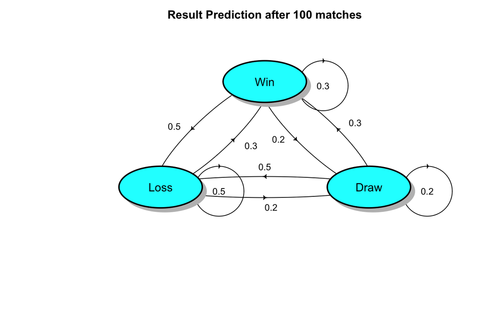

```r
plotmat(t(after_two_match),pos = c(1,2),
        lwd = 1, box.lwd = 2,
        cex.txt = 0.8,
        box.size = 0.1,
        box.type = "circle",
        box.prop = 0.5,
        box.col = "cyan",
        arr.length=.1,
        arr.width=.1,
        self.cex = .6,
        self.shifty = -.01,
        self.shiftx = .14,
        main = "Result Prediction after 100 matches")
```

**Simulation of Multinomial Markov Chain** We will use transition matrix calculted before for our simulation. The values would refer to the following states. Win->1 Loss->2 Draw->3

```r
round(tm_result,1)
```

```
     Win Loss Draw
Win  0.6  0.2  0.2
Loss 0.1  0.7  0.2
Draw 0.3  0.5  0.2
```

```r
run.mc.sim <- function( P, t) {

  # number of possible states
  num.states <- nrow(P)
  print("num.states")
  print(num.states)

  # stores the states X_t through time
  states <- numeric(t)
  print('the value of state is:')
  print(states)

  # initialize variable for first state
  states[1]    <- 1


  for(i in 2:t) { #i=2
    # probability vector to simulate next state X_{t+1}
    a<-states[i-1]
    print("the value of a is")
    print( a)
    pt  <- P[a, ]
    print("THe value of pt")
    print(pt)
    ## draw from multinomial and determine state

    states[i] <-  which(rmultinom(1, 1, pt) == 1)
    print("value of states after rmul")
    print(states[i])
  }

  return(states)

}
```

```r
# setup transition matrix p, here we will use transition_matrix_weather

P <- tm_result

#num.iterations

t=20

MC<-run.mc.sim(P,t)
```

[output not shown]

[output cut: 122 more lines]

```r
MC
```

```
 [1] 1 1 1 2 2 2 2 2 2 2 3 2 3 2 3 2 2 2 2 2
```

```r
plot(MC,type="b",col='red',pch="*")

MC2<-run.mc.sim(P,t)
```

[output not shown]

[output cut: 122 more lines]

```r
MC2
```

```
 [1] 1 1 1 1 1 3 1 2 2 3 2 2 2 2 2 2 2 3 2 2
```

```r
lines(MC2,type="b",col='cyan',pch="*")
```

```r
MC3<-run.mc.sim(P,t)
```

[output not shown]

[output cut: 122 more lines]

```r
MC3
```

```
 [1] 1 2 3 3 2 2 2 1 2 2 2 2 3 3 2 2 2 2 2 2
```

```r
lines(MC3,type="b",col='green',pch="*")

MC4<-run.mc.sim(P,t)
```

[output not shown]

[output cut: 122 more lines]

```r
MC4
```

```
 [1] 1 1 1 3 1 1 1 1 1 3 1 3 2 2 2 2 2 2 1 1
```

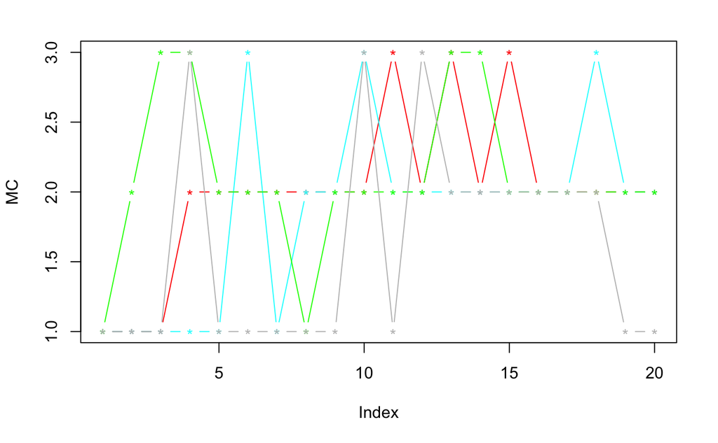

```r
lines(MC4,type="b",col='grey',pch="*")
```

```r
steadyStates(transition_matrix_result)
```

```
      Win Loss Draw
[1,] 0.28 0.52  0.2
```

```r
after_hundred_match
```

```
     Win Loss Draw
Win  0.3  0.5  0.2
Loss 0.3  0.5  0.2
Draw 0.3  0.5  0.2
```